# Supplemental Materials: Cognitive effort-based decision-making across experimental and daily life indices in younger and older adults

Jennifer L. Crawford

2022-09-27

```r
rm(list=ls())

# Packages
library(lme4); library(lmerTest); library(sjstats); library(sjPlot); library(ggeffects); library(performance); library(ggpubr); library(knitr); library(RColorBrewer); library(tidyverse);
source("summarySEwithin2.R")

#Create data directories
coged.path<-"https://raw.githubusercontent.com/jlcrawford/OA_CogED_online/master/Data/gain_loss_coged_SHARE.csv"
coged.full.path <-"https://raw.githubusercontent.com/jlcrawford/OA_CogED_online/master/Data/gain_loss_coged_full_SHARE.csv"
EMA.path <- "https://raw.githubusercontent.com/jlcrawford/OA_CogED_online/master/Data/CogEffort_ExpSamp_SHARE.csv"

#Make data frames for Cog-ED
coged<- read.csv(coged.path, header = T)
coged.full <-read.csv(coged.full.path, header = T)
```

```r
#Pulling out participant IDs for completed Cog-ED runs
Subject.IDs <- coged %>% filter(completed == 1) %>% select(subjectid) %>% distinct(subjectid, .keep_all = TRUE)
```

## Participant demographic information

As reported in the main text of the manuscript, the full sample demographics is as follows: 310 participants (190 females; Mean age = 26.2, SD= 6.3 [younger adults]; Mean age = 65.6, SD = 5.2 [older adults]; 1 American Indian or Alaskan Native, 13 Asian, 30 Black or African American, 252 White, 14 more than 1 race; 29 Hispanic or Latinx). For the EMA sample, the demographics are as follows: 230 participants (145 females; Mean age = 26.1, SD= 6.3 [younger adults]; Mean age = 65.5, SD = 5.2 [older adults]; 1 American Indian or Alaskan Native, 11 Asian, 21 Black or African American, 188 White, 9 more than 1 race; 23 Hispanic or Latinx).

## Summarizing N-Back performance (from familiarization phase)

Participants first completed a familiarization phase in which they performed four levels of the N-Back (N= 1-4) in ascending order. Within each block of the N-Back, there were 20 trials, 25% of which were targets (i.e., 5 target trials per level of N). Below, we have summarized the accuracy (hit rate) and reaction time (milliseconds) for each age group. We do observe differences in task performance with respect to hit rate across levels of task difficulty, but not age group. However, overall, older adults are slower than younger adults. Although the findings with regard to age group and hit rate are not necessarily expected, we suspect this is due to potentially higher performing older adults and lower performing younger adults, relative to the samples that are normally studied in the laboratory environment. Furthermore, the number of trials of each level of N, was designed to familiarize participants with each level of the task, but is not ideal for conducting in-depth analyses of N-Back performance (i.e., each level of N only has 5 target trials). Taken together, the N-Back performance findings should be considered cautiously.

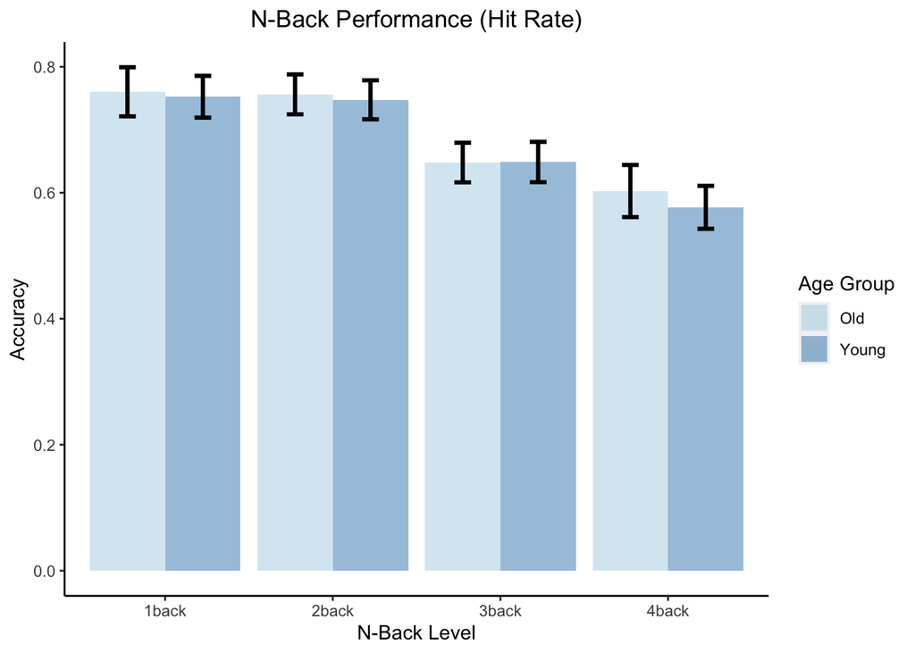

```r
#clean data frame with Cog-ED SV estimates and transform data across so that SV estimates are equivalent across both domains (i.e., gain, loss)
d.coged <- coged %>% distinct(subjectid, .keep_all = TRUE) %>% inner_join(Subject.IDs, by = "subjectid") %>% select(subjectid, ageGroup, taskOrder, IP12_1, IP12_2, IP12_3, IP13_1, IP13_2, IP13_3, IP14_1, IP14_2, IP14_3,IP12_1_loss, IP12_2_loss, IP12_3_loss, IP13_1_loss, IP13_2_loss, IP13_3_loss, IP14_1_loss, IP14_2_loss, IP14_3_loss, hitrate_N1, hitrate_N2, hitrate_N3, hitrate_N4) %>%
  group_by(subjectid, ageGroup) %>%
  mutate(SV_red__gain = (IP12_1/2 + IP12_2/3 + IP12_3/4)/3,
         SV_blue__gain = (IP13_1/2 + IP13_2/3 + IP13_3/4)/3,
         SV_purple__gain = (IP14_1/2 + IP14_2/3 + IP14_3/4)/3,
         SV_red__loss = ((IP12_1_loss/2 + IP12_2_loss/3 + IP12_3_loss/4)/3)*-1,
         SV_blue__loss = ((IP13_1_loss/2 + IP13_2_loss/3 + IP13_3_loss/4)/3)*-1,
         SV_purple__loss = ((IP14_1_loss/2 + IP14_2_loss/3 + IP14_3_loss/4)/3)*-1,
         mean_HitRate = (hitrate_N1 + hitrate_N2 + hitrate_N3 + hitrate_N4)/4)

Cog_ED_ind_SV <- d.coged %>%
  mutate(meanSV_gain = (SV_red__gain + SV_blue__gain + SV_purple__gain)/3,
         meanSV_loss = (SV_red__loss + SV_blue__loss + SV_purple__loss)/3,
         mean_HitRate = (hitrate_N1 + hitrate_N2 + hitrate_N3 + hitrate_N4)/4,
         LossGain_diff = meanSV_loss-meanSV_gain,
         GainLoss_diff = meanSV_gain-meanSV_loss,
         GainLoss_index = (meanSV_gain-meanSV_loss)/(meanSV_gain + meanSV_loss),
         GainLoss_avg = (meanSV_loss + meanSV_gain)/2)
Cog_ED_ind_SV$meanSV_gain_c <- scale(Cog_ED_ind_SV$meanSV_gain, center = T, scale = F)
Cog_ED_ind_SV$meanSV_loss_c <- scale(Cog_ED_ind_SV$meanSV_loss, center = T, scale = F)

#summarizing N-Back performance
d.NBack <- d.coged %>% select(subjectid, ageGroup, hitrate_N1, hitrate_N2, hitrate_N3, hitrate_N4) %>%
  pivot_longer(names_to = "tmp", values_to = "Performance", -c(subjectid, ageGroup)) %>%
  separate(col = tmp, into=c("TaskAttrib","Task"), sep = "_") %>%
  mutate(taskCode = factor(Task, levels = c("N1","N2","N3","N4"), labels = c(0,1,2,3)),
         ageCode = factor(ageGroup, levels = c("Young","Old"), labels = c(0,1)))
d.NBack$taskCode <- as.numeric(as.character(d.NBack$taskCode))
d.NBack$ageCode <- as.numeric(as.character(d.NBack$ageCode))

sum.NBack <- summarySEwithin2(data = d.NBack, measurevar = "Performance", withinvars = "Task", betweenvars = "ageGroup", idvar = "subjectid")

sum.NBack$Task <- factor(sum.NBack$Task, levels = c("N1","N2","N3","N4"), labels = c("1back","2back","3back","4back"))
p.nback <- ggplot(sum.NBack, aes(x=Task, y=Performance, fill=ageGroup)) +
  theme(plot.title = element_text(hjust = 0.5), panel.grid.major = element_blank(), panel.grid.minor = element_blank(), panel.background = element_blank(), axis.line = element_line(colour = "black")) +
  geom_bar(stat="identity", position=position_dodge(), alpha=.45, size=1.1) +
  geom_errorbar(position=position_dodge(width=0.9), aes(ymin=Performance-ci, ymax=Performance+ci), width=.2, size=1.1) +
  xlab("N-Back Level") + ylab("Accuracy") + ggtitle("N-Back Performance (Hit Rate)")
p.nback + labs(fill = "Age Group") + scale_fill_brewer(palette = "Paired")
```

```r
#model of N-Back hit rate predicted by task level and age group
m.nback.HR <- lmer(data = d.NBack, Performance ~ taskCode + ageCode + (1| subjectid))
tab_model(m.nback.HR, pred.labels = c("Intercept", "Task Level", "Age Group"), dv.labels = c("N-Back Peformance (Hit Rate)"), show.stat = T, show.icc = F, show.re.var = F, show.obs = F, show.r2 = F)
```

|  | N-Back Peformance (Hit Rate) |  |  |  |
| --- | --- | --- | --- | --- |
| Predictors | Estimates | CI | Statistic | p |
| Intercept | 0.77 | 0.74 – 0.81 | 43.64 | **<0.001** |
| Task Level | -0.06 | -0.07 – -0.05 | -10.98 | **<0.001** |
| Age Group | 0.01 | -0.03 – 0.06 | 0.46 | 0.649 |
| N <sub>subjectid</sub> | 310 |  |  |  |

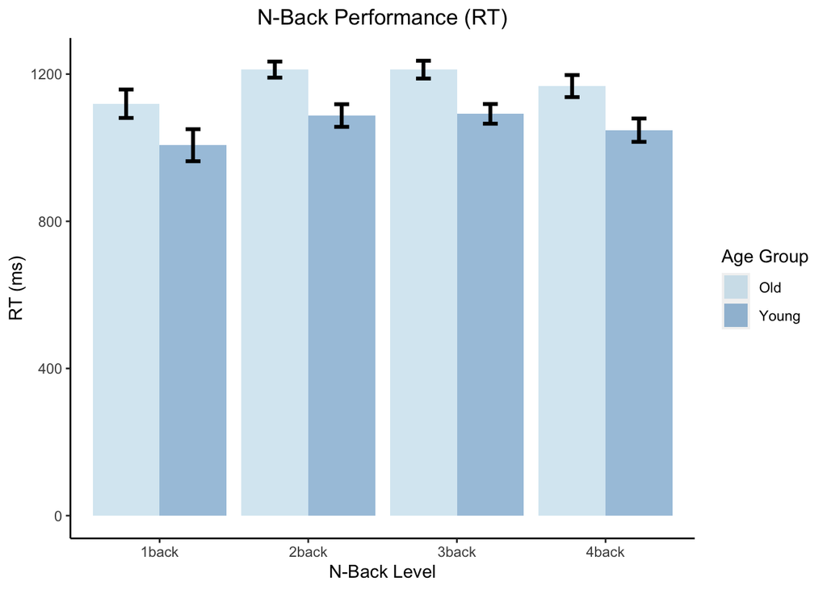

```r
#summarizing N-Back performance
d.NBack.RT <- coged.full %>% rename(subjectid = "subject") %>% select(subjectid, ageGroup, blockcode, phase, correct, latency) %>%
  filter(phase == 1) %>% filter(blockcode != "ratingSummary") %>% filter(blockcode != "nbackIntro") %>%
  group_by(subjectid, ageGroup, blockcode) %>% summarise(Acc = sum(correct)/20, RT = mean(latency)) %>% inner_join(Subject.IDs)
d.NBack.RT$taskCode <- factor(d.NBack.RT$blockcode, levels = c("1back","2back","3back","4back"), labels = c(0,1,2,3))
d.NBack.RT$taskCode <- as.numeric(as.character(d.NBack.RT$taskCode))
d.NBack.RT$ageCode <- factor(d.NBack.RT$ageGroup, levels = c("Young","Old"), labels = c(0,1))
d.NBack.RT$ageCode <- as.numeric(as.character(d.NBack.RT$ageCode))

sum.NBack.RT <- summarySEwithin2(data = d.NBack.RT, measurevar = "RT", withinvars = "blockcode", betweenvars = "ageGroup", idvar = "subjectid")

p.nback.RT <- ggplot(sum.NBack.RT, aes(x=blockcode, y=RT, fill=ageGroup)) +
  theme(plot.title = element_text(hjust = 0.5), panel.grid.major = element_blank(), panel.grid.minor = element_blank(), panel.background = element_blank(), axis.line = element_line(colour = "black")) +
  geom_bar(stat="identity", position=position_dodge(), alpha=.45, size=1.1) +
  geom_errorbar(position=position_dodge(width=0.9), aes(ymin=RT-ci, ymax=RT+ci), width=.2, size=1.1) +
  xlab("N-Back Level") + ylab("RT (ms)") + ggtitle("N-Back Performance (RT)")
p.nback.RT + labs(fill = "Age Group") + scale_fill_brewer(palette = "Paired")
```

```r
#model of N-Back RT predicted by task level and age group
m.nback.RT <- lmer(data = d.NBack.RT, RT ~ taskCode + ageCode + (1| subjectid))
tab_model(m.nback.RT, pred.labels = c("Intercept", "Task Level", "Age Group"), dv.labels = c("N-Back Peformance (RT)"), show.stat = T, show.icc = F, show.re.var = F, show.obs = F, show.r2 = F)
```

|  | N-Back Peformance (RT) |  |  |  |
| --- | --- | --- | --- | --- |
| Predictors | Estimates | CI | Statistic | p |
| Intercept | 1038.20 | 992.52 – 1083.88 | 44.54 | **<0.001** |
| Task Level | 13.51 | 3.33 – 23.69 | 2.60 | **0.009** |
| Age Group | 119.38 | 56.64 – 182.12 | 3.73 | **<0.001** |
| N <sub>subjectid</sub> | 310 |  |  |  |

## Adding N-Back performance to the models predicting Subjective Value (SV)

In additional exploratory analyses we controlled for the familiarization phase performance variables (e.g., N-Back hit rate, reaction time) when modeling the relationship between variables of interest (e.g., task level, condition, age group) and the costs of cognitive effort. We did not find any evidence that hit rate was a significant predictor of cognitive effort costs, B = 0.04 [-0.12, 0.19], t = 0.45, p = 0.655. In contrast, we did find an effect of reaction time on cognitive effort costs, B = 0.17 [0.05, 0.28], t = 2.90, p = 0.004, wherein participants who performed the N-Back more slowly had higher subjective value estimates (i.e., lower cognitive effort costs). Nevertheless, and most critically, even when controlling for these performance variables, we still observed the previously reported effects of task level, condition, age group, and the task level × condition interaction on subjective value, ps < 0.011 (see Table below), demonstrating that cognitive effort costs cannot be explained only by task performance.

```r
d.coged.SV <- d.coged %>% select(subjectid, ageGroup, taskOrder, SV_red__gain, SV_blue__gain, SV_purple__gain, SV_red__loss, SV_blue__loss, SV_purple__loss, mean_HitRate) %>%
  pivot_longer(names_to = "tmp", values_to = "SV", -c(subjectid, ageGroup, taskOrder, mean_HitRate)) %>%
  separate(col = tmp, into=c("Task","Condition"), sep = "__") %>%
  separate(col = Task, into=c(NA,"Task"), sep = "_") %>%
  mutate(Condition = factor(Condition, levels = c("gain","loss"), labels = c("Gain","Loss")),
         taskCode = factor(Task, levels=c("red","blue","purple"), labels=c(-1,0,1)),
         conditionCode = factor(Condition, levels = c("Gain","Loss"), labels = c(0,1)),
         ageCode = factor(ageGroup, levels = c("Young", "Old"), labels = c(0,1)),
         orderCode = factor(taskOrder, levels = c(1,2), labels = c(0,1)))
d.coged.SV$taskCode <- as.numeric(as.character(d.coged.SV$taskCode))
d.coged.SV$conditionCode <- as.numeric(as.character(d.coged.SV$conditionCode))
d.coged.SV$ageCode <- as.numeric(as.character(d.coged.SV$ageCode))
d.coged.SV$orderCode <- as.numeric(as.character(d.coged.SV$orderCode))

d.NBack.RT.ind <- d.NBack.RT %>% group_by(subjectid) %>% summarise(meanRT = mean(RT)) %>%
                        mutate(meanRT_s = meanRT/1000)
d.coged.SV <- inner_join(d.coged.SV, d.NBack.RT.ind)
d.coged.SV$Task <- factor(d.coged.SV$Task, levels = c("red","blue","purple"), labels = c("2-Back","3-Back","4-Back"))

#adding n-back task performance (meanRT) to the model predicting SV
m.coged.nback.RT <- lmer(data = d.coged.SV, SV ~ taskCode*conditionCode*ageCode + mean_HitRate + meanRT_s + (1 | subjectid))
tab_model(m.coged.nback.RT, pred.labels = c("Intercept", "Task Level", "Condition", "Age Group", "Mean Hit Rate", "Mean RT (sec)", "Task Level * Condition", "Task Level * Age Group", "Condition * Age Group", "Task Level * Condition * Age Group"), dv.labels = c("Subjective Value"), show.stat = T, show.icc = F, show.re.var = F, show.obs = F, show.r2 = F)
```

|  | Subjective Value |  |  |  |
| --- | --- | --- | --- | --- |
| Predictors | Estimates | CI | Statistic | p |
| Intercept | 0.41 | 0.22 – 0.60 | 4.14 | **<0.001** |
| Task Level | -0.14 | -0.16 – -0.11 | -10.37 | **<0.001** |
| Condition | 0.07 | 0.04 – 0.10 | 4.33 | **<0.001** |
| Age Group | -0.14 | -0.21 – -0.08 | -4.39 | **<0.001** |
| Mean Hit Rate | 0.04 | -0.12 – 0.19 | 0.45 | 0.655 |
| Mean RT (sec) | 0.17 | 0.05 – 0.28 | 2.90 | **0.004** |
| Task Level * Condition | 0.05 | 0.01 – 0.08 | 2.53 | **0.011** |
| Task Level * Age Group | 0.02 | -0.02 – 0.06 | 0.95 | 0.340 |
| Condition * Age Group | -0.02 | -0.06 – 0.02 | -0.88 | 0.379 |
| Task Level * Condition * Age Group | -0.00 | -0.06 – 0.05 | -0.10 | 0.919 |
| N <sub>subjectid</sub> | 310 |  |  |  |

## Adding NASA-TLX variables (performance, frustration) to the models predicting Subjective Value (SV)

Further exploratory analyses controlled for self-reported frustration and performance variables taken from the NASA-TLX when modeling the relationship between variables of interest (e.g., task level, condition, age group) and the costs of cognitive effort. We did not find any evidence that self-reported performance was a significant predictor of cognitive effort costs above objective task performance variables, B = -0.004 [-0.01, 0.01], t = -0.80, p = 0.423. In contrast, we did find an effect of self-reported frustration on cognitive effort costs, B = -0.01 [-0.01, -0.00], t = -2.05, p = 0.040, such that participants who had higher levels of self-reported frustration after performing the N-Back had lower subjective value estimates (i.e., higher cognitive effort costs). Importantly, even when controlling for these self-reported variables, we still observed the previously reported effects of task level, condition, age group, and the task level × condition interaction on subjective value, ps < 0.011 (see Table below), demonstrating that cognitive effort costs cannot be explained only by performance and frustration variables.

```r
#clean data frame with Cog-ED SV estimates and transform data across so that SV estimates are equivalent across both domains (i.e., gain, loss)
NASA <- coged %>% distinct(subjectid, .keep_all = TRUE) %>% inner_join(Subject.IDs, by = "subjectid") %>% select(subjectid, ageGroup, frustration_1, frustration_2, frustration_3, frustration_4, performance_1, performance_2, performance_3, performance_4) %>%
  group_by(subjectid, ageGroup) %>%
  mutate(mean_Frust = (frustration_1 + frustration_2 +frustration_3 +frustration_4)/4,
         mean_Perform = (performance_1 + performance_2 + performance_3 + performance_4)/4) %>%
  select(subjectid, ageGroup, mean_Frust, mean_Perform)

d.coged.SV <- inner_join(d.coged.SV, NASA)

#adding NASA to the model predicting SV
m.coged.NASA <- lmer(data = d.coged.SV, SV ~ taskCode*conditionCode*ageCode + mean_HitRate + meanRT_s + mean_Frust + mean_Perform + (1 | subjectid))
tab_model(m.coged.NASA, pred.labels = c("Intercept", "Task Level", "Condition", "Age Group", "Mean Hit Rate", "Mean RT (sec)","Self-Reported Frustration", "Self-Reported Performance", "Task Level * Condition", "Task Level * Age Group", "Condition * Age Group", "Task Level * Condition * Age Group"), dv.labels = c("Subjective Value"), show.stat = T, show.icc = F, show.re.var = F, show.obs = F, show.r2 = F)
```

|  | Subjective Value |  |  |  |
| --- | --- | --- | --- | --- |
| Predictors | Estimates | CI | Statistic | p |
| Intercept | 0.53 | 0.30 – 0.76 | 4.54 | **<0.001** |
| Task Level | -0.14 | -0.16 – -0.11 | -10.37 | **<0.001** |
| Condition | 0.07 | 0.04 – 0.10 | 4.33 | **<0.001** |
| Age Group | -0.15 | -0.21 – -0.08 | -4.55 | **<0.001** |
| Mean Hit Rate | 0.06 | -0.14 – 0.26 | 0.56 | 0.577 |
| Mean RT (sec) | 0.16 | 0.04 – 0.28 | 2.69 | **0.007** |
| Self-Reported Frustration | -0.01 | -0.01 – -0.00 | -2.05 | **0.040** |
| Self-Reported Performance | -0.00 | -0.01 – 0.01 | -0.80 | 0.423 |
| Task Level * Condition | 0.05 | 0.01 – 0.08 | 2.53 | **0.011** |
| Task Level * Age Group | 0.02 | -0.02 – 0.06 | 0.95 | 0.340 |
| Condition * Age Group | -0.02 | -0.06 – 0.02 | -0.88 | 0.379 |
| Task Level * Condition * Age Group | -0.00 | -0.06 – 0.05 | -0.10 | 0.919 |
| N <sub>subjectid</sub> | 310 |  |  |  |

# EMA Data

```r
#Import concatenated EMA data
codebook.path <- "https://raw.githubusercontent.com/jlcrawford/OA_CogED_online/master/Data/Codebook.csv"
codebook <- read.csv(codebook.path, header = T)
#create list of new variable names from codebook
new.names <- codebook$new_itemname

#read in EMA data
EMA<- read.csv(EMA.path, header = T) %>% inner_join(Subject.IDs, by = "subjectid")

#clean up extraneous variables from Qualtrics survey
EMA.clean <- EMA %>% select(-c(EndDate, RecordedDate, Status, IPAddress, Progress, Finished, ResponseId, RecipientLastName, RecipientFirstName, RecipientEmail, ExternalReference,LocationLatitude,LocationLongitude, DistributionChannel, UserLanguage, SC0)) %>%
  setNames(new.names) %>%
  separate(date, c("date", "time"), sep = " ") %>%
  mutate(Date = as.Date.character(date, "%m/%d/%y"),
         day = weekdays(Date),
         timeDay = if_else(time < 12, "morning", if_else(time > 18, "evening", "afternoon")))
```

## Current Activities

```r
#Individual pie chart for item "What are you doing right now"
activities.string <- paste(EMA.clean$activities, collapse = "," )
activity.vector <- str_split(activities.string, ',')[[1]]
activity.clean <- data_frame(activity.vector)
activity_freq <- activity.clean %>% group_by(activity.vector) %>% tally() %>% filter(activity.vector !="") %>%
  rename(activity = activity.vector) %>%
  mutate(percentage = (n / sum(n))*100)
activity_freq$activity <- factor(activity_freq$activity, levels=c(1,2,14,12,16,4,7,20,21,6,19,10,8,5,15,9,3,13,17,18,11), labels=c("Eating or Drinking","TV", "Computer", "In Transit", "Reading", "Socializing", "Sleeping", "Chores","Listening to Speech", "Work", "Hygiene", "Cooking", "Errands", "Exercise", "Radio", "Cleaning", "Entertainment", "Nothing in Particular", "School", "Volunteering", "Doctor's Appointment"))

kable(activity_freq, caption =  "Frequency of Current Activities")
```

Frequency of Current Activities

| activity | n | percentage |
| --- | --- | --- |
| Eating or Drinking | 2358 | 18.1147730 |
| Cooking | 445 | 3.4186064 |
| Doctor’s Appointment | 79 | 0.6068987 |
| In Transit | 492 | 3.7796727 |
| Nothing in Particular | 370 | 2.8424368 |
| Computer | 1746 | 13.4132289 |
| Radio | 268 | 2.0588461 |
| Reading | 523 | 4.0178228 |
| School | 221 | 1.6977798 |
| Volunteering | 41 | 0.3149727 |
| Hygiene | 485 | 3.7258969 |
| TV | 1603 | 12.3146654 |
| Chores | 545 | 4.1868326 |
| Listening to Speech | 102 | 0.7835907 |
| Entertainment | 86 | 0.6606745 |
| Socializing | 733 | 5.6310978 |
| Exercise | 288 | 2.2124914 |
| Work | 1193 | 9.1649382 |
| Sleeping | 680 | 5.2239379 |
| Errands | 380 | 2.9192594 |
| Cleaning | 379 | 2.9115772 |

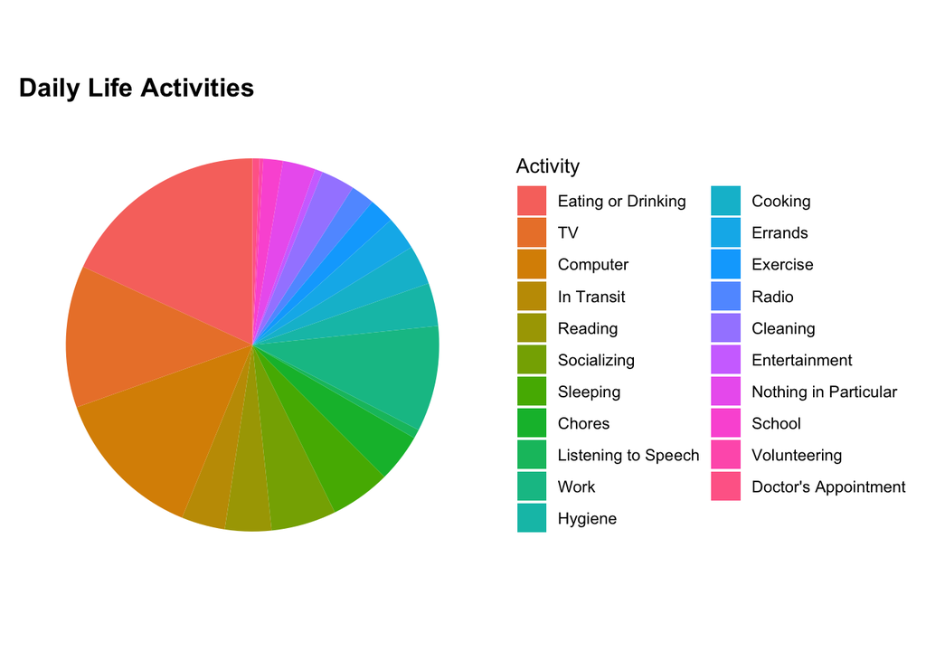

```r
current.activities <- ggplot(activity_freq, aes(x = "" , y= percentage, fill=activity)) +
geom_bar(width = 1, stat = "identity") + ggtitle("Daily Life Activities")

blank_theme <- theme_minimal() + theme(axis.title.x = element_blank(),
axis.title.y = element_blank(),panel.border = element_blank(),
panel.grid=element_blank(),axis.ticks = element_blank(),
plot.title=element_text(size=14, face="bold"))

pie_current_activity <- current.activities + coord_polar("y", start=0) + blank_theme +
theme(axis.text.x=element_blank())

pie_current_activity + scale_fill_discrete(name = "Activity")
```

## Mental Demand of Current Activities

Here, we have summarized the average mental demand and variability of mental demand ratings for each activity across both younger and older adults. These results are further visualized with a bar plot, which summarizes the average mental demand of each of the activities across both age groups (error bars = standard error). Overall, younger adults tend to report higher levels of mental demand across a variety of activities in daily life. Furthermore, there is face validity to these ratings in that activities, such as working and volunteering, are rated higher in mental demand relative to activities, such as watching tv or eating and drinking.

```r
#create data frame of mental demand ratings
m.demand <- EMA.clean %>% select(subjectid,ageGroup,time,timeDay,day,starts_with("demand_")) %>%
  pivot_longer(names_to = "category", values_to = "rating", -c(subjectid, ageGroup, time, timeDay, day)) %>%
  separate(col = category, into=c(NA,"Category"), sep = "_")

#summarizing average mental demand of activities across all participants
m.demand.subj <-m.demand %>% group_by(subjectid,ageGroup,Category) %>%
  summarise(mean.demand = mean(rating, na.rm = T),
            iSD.demand = sd(rating, na.rm=T))

#table summary of mean and iSD of mental demand across age group and activity category
m.demand.sum <- summarySEwithin2(m.demand.subj, measurevar = "mean.demand", withinvars = c("Category"), betweenvars = "ageGroup", idvar = "subjectid")

table.demand <- m.demand.sum %>% select(Category, mean.demand) %>% kable(caption =  "Average Mental Demand for Current Activities")
table.demand
```

Average Mental Demand for Current Activities

| Category | mean.demand |
| --- | --- |
| chores | 1.843466 |
| cleaning | 1.753653 |
| computer | 2.282233 |
| cooking | 1.887280 |
| doctor | 2.339286 |
| eat | 1.196201 |
| entertain | 1.921053 |
| errand | 2.059108 |
| exercise | 1.773081 |
| hygeine | 1.252805 |
| nothing | 1.246857 |
| radio | 1.315465 |
| reading | 2.106785 |
| school | 2.500000 |
| sleep | 1.132096 |
| social | 1.789159 |
| speech | 2.470667 |
| transit | 2.227263 |
| tv | 1.291206 |
| volunteer | 2.650000 |
| work | 3.038824 |
| chores | 2.144004 |
| cleaning | 2.191289 |
| computer | 2.097565 |
| cooking | 2.053052 |
| doctor | 2.998246 |
| eat | 1.362618 |
| entertain | 2.184921 |
| errand | 2.332222 |
| exercise | 2.494286 |
| hygeine | 1.656592 |
| nothing | 1.365923 |
| radio | 1.458333 |
| reading | 2.295110 |
| school | 3.394524 |
| sleep | 1.217452 |
| social | 1.940475 |
| speech | 2.411000 |
| transit | 2.107403 |
| tv | 1.303176 |
| volunteer | 3.062500 |
| work | 2.971838 |

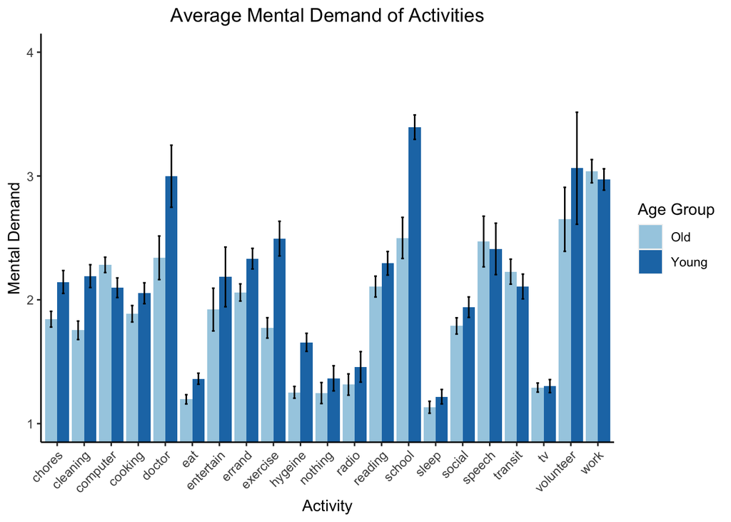

```r
#plotting mental demand associated with each of the surveyed activities
p.mental.demand <- ggplot(m.demand.sum, aes(x = Category, y= mean.demand, fill=ageGroup)) +
 theme(plot.title = element_text(hjust = 0.5), panel.grid.major = element_blank(), panel.grid.minor = element_blank(), panel.background = element_blank(), axis.line = element_line(colour = "black"), axis.text.x = element_text(angle = 45, hjust = 1)) +
  geom_bar(stat="identity", position=position_dodge()) +
  geom_errorbar(position=position_dodge(width=0.9), aes(ymin=mean.demand-se, ymax=mean.demand+se), width=.2) +
  coord_cartesian(ylim=c(1,4)) +
  xlab("Activity") + ylab("Mental Demand") + ggtitle("Average Mental Demand of Activities")
p.mental.demand + labs(fill = "Age Group") + scale_fill_brewer(palette = "Paired")
```

```r
m.demand.iSD.sum <- summarySEwithin2(m.demand.subj, measurevar = "iSD.demand", withinvars = c("Category"), betweenvars = "ageGroup", idvar = "subjectid")

table.demand.isd <- m.demand.iSD.sum %>% select(Category, iSD.demand) %>% kable(caption =  "Variayion in Mental Demand Ratings for Current Activities")
table.demand.isd
```

Variayion in Mental Demand Ratings for Current Activities

| Category | iSD.demand |
| --- | --- |
| chores | 0.4876137 |
| cleaning | 0.3897638 |
| computer | 0.6497694 |
| cooking | 0.4350376 |
| doctor | 0.5440038 |
| eat | 0.2755908 |
| entertain | 0.3096161 |
| errand | 0.5265199 |
| exercise | 0.4411277 |
| hygeine | 0.2845569 |
| nothing | 0.3348337 |
| radio | 0.3552398 |
| reading | 0.4110450 |
| school | 0.0000000 |
| sleep | 0.1408252 |
| social | 0.5896994 |
| speech | 0.5458857 |
| transit | 0.5418933 |
| tv | 0.2955580 |
| volunteer | 0.1154701 |
| work | 0.5928018 |
| chores | 0.5108589 |
| cleaning | 0.4787034 |
| computer | 0.6451074 |
| cooking | 0.4695623 |
| doctor | 0.6186930 |
| eat | 0.4003336 |
| entertain | 0.4103311 |
| errand | 0.6041707 |
| exercise | 0.4915198 |
| hygeine | 0.5197807 |
| nothing | 0.3627185 |
| radio | 0.3159829 |
| reading | 0.6808436 |
| school | 0.7248131 |
| sleep | 0.2184393 |
| social | 0.5431759 |
| speech | 0.6715778 |
| transit | 0.7601926 |
| tv | 0.3021925 |
| volunteer | 0.7071068 |
| work | 0.6365880 |

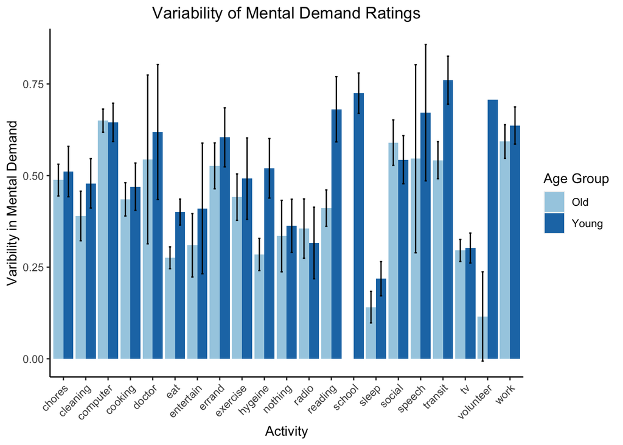

```r
#plotting mental demand associated with each of the surveyed activities
p.mental.demand.iSD <- ggplot(m.demand.iSD.sum, aes(x = Category, y= iSD.demand, fill=ageGroup)) +
 theme(plot.title = element_text(hjust = 0.5), panel.grid.major = element_blank(), panel.grid.minor = element_blank(), panel.background = element_blank(), axis.line = element_line(colour = "black"), axis.text.x = element_text(angle = 45, hjust = 1)) +
  geom_bar(stat="identity", position=position_dodge()) +
  geom_errorbar(position=position_dodge(width=0.9), aes(ymin=iSD.demand-se, ymax=iSD.demand+se), width=.2) +
  xlab("Activity") + ylab("Varibility in Mental Demand") + ggtitle("Variability of Mental Demand Ratings")
p.mental.demand.iSD + labs(fill = "Age Group") + scale_fill_brewer(palette = "Paired")
```

In addition, we have summarized the mental demand ratings by the frequency with which participants are reporting them in daily life; as is evident from the histogram, the vast majority of daily life activities across both younger and older adults are low in mental demand.

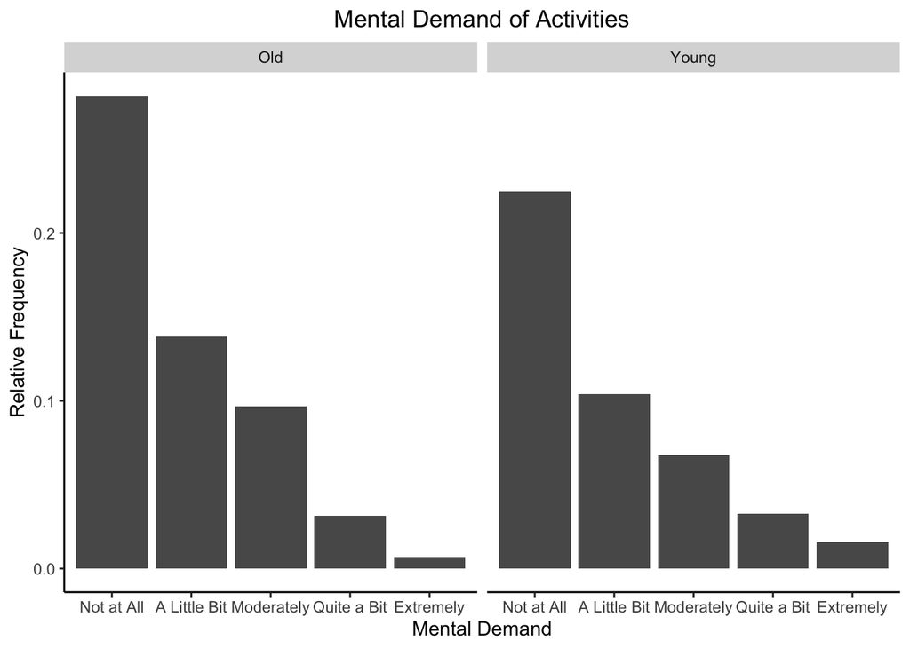

```r
#plotting mental demand as a frequency of reported daily life activities
m.demand.sum$Category <- factor(m.demand.sum$Category, levels = c("work", "volunteer", "doctor", "transit", "social", "exercise", "computer", "cleaning", "entertain", "cooking", "reading", "errand", "chores", "radio", "hygeine", "tv", "nothing", "eat", "sleep"), labels = c("Work", "Volunteering", "Doctor's Appt.", "In Transit", "Socializing", "Exercising", "Computer", "Cleaning", "Entertainment", "Cooking", "Reading", "Errands", "Chores", "Radio", "Hygiene", "TV", "Nothing in Particular", "Eating/Drinking", "Sleeping"))

#tabulating frequency of mental demand ratings (from 5-point likert scale)
m.demand$rating <- factor(m.demand$rating, levels=c(1,2,3,4,5), labels = c("Not at All","A Little Bit","Moderately", "Quite a Bit", "Extremely"))
m.demand.freq <- m.demand %>% group_by(rating, ageGroup) %>% filter(rating != "NA") %>%
  summarise (n=n(), .groups = "drop") %>%
  mutate(rel.freq =  (n/sum(n)))

#plotting frequency of mental demand in daily life
m.demand.frequency <- ggplot(m.demand.freq, aes(x = rating, y= rel.freq)) +
 theme(plot.title = element_text(hjust = 0.5), panel.grid.major = element_blank(), panel.grid.minor = element_blank(), panel.background = element_blank(), axis.line = element_line(colour = "black")) + scale_x_discrete(limits=c("Not at All","A Little Bit","Moderately", "Quite a Bit", "Extremely")) +
  geom_bar(stat="identity", position=position_dodge()) + ggtitle("Mental Demand of Activities") + xlab("Mental Demand") + ylab("Relative Frequency") +
  facet_wrap(.~ageGroup)
m.demand.frequency
```

## Control Analysis: Checking for multicollinearity in the Daily Life Mental Demand Multilevel Model

Because the zero-order correlations between the gain and loss subjective value estimates are highly correlated within participants in both younger, r = 0.58 [0.47, 0.68], t = 9.14, p < 0.001, and older adults, r = 0.54 [0.41, 0.64], t = 7.66, p < 0.001, we checked for multicollinearity in our model predicting daily life mental demand in which both gain and loss subjective values estimates (and their interactions with age group) were included as predictors. In the multilevel model predicting daily life mental demand, we used the centered subjective value estimates as predictors and as can be seen from the results below, the variance inflation factor for all predictors in the model are relatively low, suggesting that multicollinearity is not a concern for this model of interest.

```r
#create data frame of mental demand ratings
m.demand <- EMA.clean %>% select(subjectid,ageGroup,Date,time,timeDay,day,starts_with("demand_")) %>%
  pivot_longer(names_to = "category", values_to = "rating", -c(subjectid, ageGroup, Date, time, timeDay, day)) %>%
  separate(col = category, into=c(NA,"Category"), sep = "_")

#summarizing average mental demand of activities across all participants
m.demand.subj.av <-m.demand %>% group_by(subjectid, ageGroup) %>%
  summarise(count.survey = sum(!is.na(rating)),
         mean.demand = mean(rating, na.rm=T),
         iSD.demand = sd(rating, na.rm=T)) %>%
  filter(count.survey > 3)

m.demand.subj.IDs <- m.demand.subj.av %>% select(subjectid, ageGroup, count.survey)

#summarizing mental demand across the days of the week and time of day
m.demand.time.day <- m.demand %>% group_by(subjectid,ageGroup,Date,time,day,timeDay) %>%
  summarise(count.demand = sum(!is.na(rating)),
         mean.demand = mean(rating, na.rm=T)) %>%
  mutate(dayCode = factor(day, levels = c("Monday","Tuesday","Wednesday","Thursday","Friday","Saturday","Sunday"),
                          labels = c(0,1,2,3,4,5,6)),
         timeCode = factor(timeDay, levels = c("morning","afternoon","evening"),
                          labels = c(-1,0,1)),
         ageCode = factor(ageGroup, levels = c("Young","Old"), labels = c(0,1))) %>% inner_join(m.demand.subj.IDs) %>%
  inner_join(Cog_ED_ind_SV)
m.demand.time.day$dayCode <- as.numeric(as.character(m.demand.time.day$dayCode))
m.demand.time.day$timeCode <- as.numeric(as.character(m.demand.time.day$timeCode))
m.demand.time.day$ageCode <- as.numeric(as.character(m.demand.time.day$ageCode))

#summarizing average mental demand of activities across all participants
m.demand.subj.av.2 <-m.demand.time.day %>% group_by(subjectid, ageGroup) %>%
  summarise(count.survey = sum(!is.na(mean.demand)))

# age + day of the week + time of the day + average Gain SV + average Loss SV (with age interactions) predicting mental demand
m.mental.demand.age.timeDay.Gainloss.int<- lmer(data = m.demand.time.day, mean.demand~ ageCode + dayCode + timeCode + meanSV_gain_c*ageCode + meanSV_loss_c*ageCode + (1 | subjectid))

#check model for multicollinearity
check_collinearity(m.mental.demand.age.timeDay.Gainloss.int)
```

```
## # Check for Multicollinearity
##
## Low Correlation
##
##                   Term  VIF Increased SE Tolerance
##                ageCode 1.05         1.02      0.95
##                dayCode 1.00         1.00      1.00
##               timeCode 1.00         1.00      1.00
##          meanSV_gain_c 3.12         1.77      0.32
##          meanSV_loss_c 3.49         1.87      0.29
##  ageCode:meanSV_gain_c 3.01         1.73      0.33
##  ageCode:meanSV_loss_c 3.30         1.82      0.30
```

## Control Analysis: Adding Activity Count at Each Measurement Occasion and Total Survey Count into the Multilevel Model Predicting Mental Demand

```r
# age + day of the week + time of the day + average Gain SV + average Loss SV (with age interactions) + activity count predicting mental demand
m.mental.demand.age.timeDay.Gainloss.int.count<- lmer(data = m.demand.time.day, mean.demand ~ ageCode + dayCode + timeCode + meanSV_gain_c*ageCode + meanSV_loss_c*ageCode + count.demand + (1 | subjectid))

# age + day of the week + time of the day + average Gain SV + average Loss SV (with age interactions) + activity count predicting mental demand
m.mental.demand.age.timeDay.Gainloss.int.count.2<- lmer(data = m.demand.time.day, mean.demand~ ageCode + dayCode + timeCode + meanSV_gain_c*ageCode + meanSV_loss_c*ageCode + count.demand + count.survey + (1 | subjectid))

#table summarizing model output after adding in activity count and survey count
table.S1 <- tab_model(m.mental.demand.age.timeDay.Gainloss.int.count.2, pred.labels = c("Intercept", "Age Group", "Day of Week", "Time of Day", "SV (Gain)", "SV (Loss)","Activity Count", "Survey Count", "Age Group * SV (Gain)", "Age Group * SV (Loss)"), dv.labels = c("Mental Demand Rating"), show.stat = T, show.icc = F, show.re.var = F, show.obs = F, show.r2 = F, digits = 3)
table.S1
```

|  | Mental Demand Rating |  |  |  |
| --- | --- | --- | --- | --- |
| Predictors | Estimates | CI | Statistic | p |
| Intercept | 2.338 | 2.195 – 2.481 | 31.999 | **<0.001** |
| Age Group | -0.140 | -0.263 – -0.018 | -2.248 | **0.025** |
| Day of Week | -0.052 | -0.063 – -0.041 | -9.675 | **<0.001** |
| Time of Day | -0.036 | -0.065 – -0.007 | -2.438 | **0.015** |
| SV (Gain) | 0.774 | 0.442 – 1.105 | 4.573 | **<0.001** |
| SV (Loss) | -1.004 | -1.379 – -0.630 | -5.256 | **<0.001** |
| Activity Count | -0.157 | -0.188 – -0.127 | -10.082 | **<0.001** |
| Survey Count | 0.002 | -0.000 – 0.004 | 1.669 | 0.095 |
| Age Group * SV (Gain) | -0.496 | -0.929 – -0.062 | -2.240 | **0.025** |
| Age Group * SV (Loss) | 0.705 | 0.229 – 1.181 | 2.903 | **0.004** |
| N <sub>subjectid</sub> | 230 |  |  |  |

We sought to further characterize the relationship between activity count by testing whether the mean activity count at each measurement occasion differs by age group. Indeed, we found that on average older adults tend to endorse, and subsequently rate, more activities (M=2.03) relative to younger adults (M=1.90), t(226.5) = 2.01, p = 0.045.

```r
#does count of activities differ by age group?
count.data <- m.demand.time.day %>% select(subjectid, ageGroup, count.demand, mean_HitRate, meanSV_gain, meanSV_loss) %>% group_by(subjectid, ageGroup, mean_HitRate, meanSV_gain, meanSV_loss) %>%
  summarise(mean.count = mean(count.demand))

T.count <- t.test(data = count.data, mean.count ~ ageGroup)
T.count
```

```
##
##  Welch Two Sample t-test
##
## data:  mean.count by ageGroup
## t = 2.0117, df = 226.5, p-value = 0.04544
## alternative hypothesis: true difference in means between group Old and group Young is not equal to 0
## 95 percent confidence interval:
##  0.002769167 0.267668446
## sample estimates:
##   mean in group Old mean in group Young
##            2.034854            1.899635
```

In contrast to the preliminary findings suggesting an age group effect on activity count, we did not observe any relationship between the average number of activities participants provided mental demand ratings for either Cog-ED choice behavior or N-Back performance.

```r
count.model.HR <- lm(data = count.data, mean.count ~ mean_HitRate)
summary(count.model.HR)
```

```
##
## Call:
## lm(formula = mean.count ~ mean_HitRate, data = count.data)
##
## Residuals:
##      Min       1Q   Median       3Q      Max
## -0.96919 -0.38715  0.01584  0.39408  1.04279
##
## Coefficients:
##              Estimate Std. Error t value Pr(>|t|)
## (Intercept)    1.8794     0.1407  13.356   <2e-16 ***
## mean_HitRate   0.1197     0.1913   0.626    0.532
## ---
## Signif. codes:  0 '***' 0.001 '**' 0.01 '*' 0.05 '.' 0.1 ' ' 1
##
## Residual standard error: 0.5132 on 228 degrees of freedom
## Multiple R-squared:  0.001716,   Adjusted R-squared:  -0.002662
## F-statistic: 0.392 on 1 and 228 DF,  p-value: 0.5319
```

```r
count.model.SV <- lm(data = count.data, mean.count ~ meanSV_gain + meanSV_loss)
summary(count.model.SV)
```

```
##
## Call:
## lm(formula = mean.count ~ meanSV_gain + meanSV_loss, data = count.data)
##
## Residuals:
##      Min       1Q   Median       3Q      Max
## -0.99654 -0.37760  0.01195  0.38836  1.06172
##
## Coefficients:
##             Estimate Std. Error t value Pr(>|t|)
## (Intercept)  1.93693    0.08405  23.046   <2e-16 ***
## meanSV_gain  0.06617    0.12361   0.535    0.593
## meanSV_loss -0.01259    0.13375  -0.094    0.925
## ---
## Signif. codes:  0 '***' 0.001 '**' 0.01 '*' 0.05 '.' 0.1 ' ' 1
##
## Residual standard error: 0.5145 on 227 degrees of freedom
## Multiple R-squared:  0.001413,   Adjusted R-squared:  -0.007386
## F-statistic: 0.1606 on 2 and 227 DF,  p-value: 0.8518
```

```r
count.model.full <- lm(data = count.data, mean.count ~ meanSV_gain + meanSV_loss + mean_HitRate)
summary(count.model.full)
```

```
##
## Call:
## lm(formula = mean.count ~ meanSV_gain + meanSV_loss + mean_HitRate,
##     data = count.data)
##
## Residuals:
##      Min       1Q   Median       3Q      Max
## -1.00029 -0.38889  0.01188  0.38525  1.06932
##
## Coefficients:
##              Estimate Std. Error t value Pr(>|t|)
## (Intercept)   1.85214    0.16087  11.514   <2e-16 ***
## meanSV_gain   0.06528    0.12379   0.527    0.598
## meanSV_loss  -0.01181    0.13393  -0.088    0.930
## mean_HitRate  0.11872    0.19198   0.618    0.537
## ---
## Signif. codes:  0 '***' 0.001 '**' 0.01 '*' 0.05 '.' 0.1 ' ' 1
##
## Residual standard error: 0.5152 on 226 degrees of freedom
## Multiple R-squared:  0.0031, Adjusted R-squared:  -0.01013
## F-statistic: 0.2342 on 3 and 226 DF,  p-value: 0.8725
```

## Control Analysis: Adding Sluggishness and Arousal Ratings Completed Prior to Activity Engagement to the Multilevel Model of Daily Life Mental Demand

To better understand how participant’s energy levels impact the mental demand ratings they provide at each measurement occasion, we sought to examine whether ratings of arousal and sluggishness (as proxies of energy level) measured prior to activity participation (i.e., prior to rating of the mental demand of these activities) was a significant predictor in the multilevel model of daily life mental demand. We did not find reliable evidence that arousal ratings were related to daily life mental demand, B = 0.021 [-0.01, 0.053], t = 1.26, p = 0.210. On the other hand, we found that ratings of sluggishness were a significant predictor of daily life mental demand, B = -0.025 [-0.048, -0.002], t = -2.17, p = 0.030. These results suggest than an increase in the sluggishness rating tended be associated with a reduction in the mental demand of daily life activities completed after this rating. Neither of these effects interacted with age group. Most importantly, even after controlling for self-reported ratings of arousal and sluggishness (i.e., participant’s energy levels) in the model, we still observe significant effects cognitive effort costs across both gain and loss incentive domains and their interaction with age group (see output below). These results help to further demonstrate that there remains a strong relationship between participant’s cognitive efforts costs, as measured experimentally at a single occasion, and the mental demand of the activities they engage in during daily life across both younger and older adults. Indeed, we are excited by these results and believe that our findings only begin to scratch the surface of the potential of this type of approach that aims to understand the mechanisms that underlie cognitive effort-based decision-making in daily life using the combination of experimental and daily life sampling approaches.

```r
#creating data frame from affect ratings
affect.sluggish <- EMA.clean %>% select(subjectid,ageGroup,Date,time,timeDay,day, starts_with("affect_")) %>%
  pivot_longer(names_to = "Affect", values_to = "rating", -c(subjectid, ageGroup, Date, time, timeDay,day)) %>%
  separate(col = Affect, into=c(NA,"Affect_Term"), sep = "_") %>% arrange(subjectid, Date, time) %>%
  mutate(Valence = if_else((Affect_Term == "calm"| Affect_Term == "excited"| Affect_Term == "happy"| Affect_Term ==  "aroused"),
                           "Positive", "Negative"),
         valenceCode = factor(Valence, levels = c("Positive","Negative"), labels = c(0,1)),
         ageCode = factor(ageGroup, levels = c("Young","Old"), labels = c(0,1))) %>% rename(sluggish_rating = "rating") %>%
  filter(Affect_Term == "sluggish") %>%
  mutate(sluggish_lag = lag(sluggish_rating))
affect.sluggish$valenceCode <- as.numeric(as.character(affect.sluggish$valenceCode))
affect.sluggish$ageCode <- as.numeric(as.character(affect.sluggish$ageCode))

affect.aroused <- EMA.clean %>% select(subjectid,ageGroup,Date,time,timeDay,day, starts_with("affect_")) %>%
  pivot_longer(names_to = "Affect", values_to = "rating", -c(subjectid, ageGroup, Date, time, timeDay,day)) %>%
  separate(col = Affect, into=c(NA,"Affect_Term"), sep = "_") %>% arrange(subjectid, Date, time) %>%
  mutate(Valence = if_else((Affect_Term == "calm"| Affect_Term == "excited"| Affect_Term == "happy"| Affect_Term ==  "aroused"),
                           "Positive", "Negative"),
         valenceCode = factor(Valence, levels = c("Positive","Negative"), labels = c(0,1)),
         ageCode = factor(ageGroup, levels = c("Young","Old"), labels = c(0,1))) %>% rename(aroused_rating = "rating") %>%
  filter(Affect_Term == "aroused") %>%
  mutate(aroused_lag = lag(aroused_rating)) %>% select(aroused_rating, aroused_lag)

affect.lagged <- cbind(affect.sluggish, affect.aroused)

affect.m.demand <- m.demand.time.day %>% inner_join(affect.lagged)

# age + day of the week + time of the day + average Gain SV + average Loss SV (with age interactions)
m.mental.demand.age.timeDay.Gainloss.int<- lmer(data = affect.m.demand, mean.demand ~ ageCode + dayCode + timeCode + meanSV_gain_c*ageCode + meanSV_loss_c*ageCode + (1 | subjectid))

# age + day of the week + time of the day + average Gain SV + average Loss SV (with age interactions) + lagged sluggish rating
m.mental.demand.age.timeDay.Gainloss.int.sluggishLag<- lmer(data = affect.m.demand, mean.demand ~ ageCode + dayCode + timeCode + meanSV_gain_c*ageCode + meanSV_loss_c*ageCode + sluggish_lag + (1 | subjectid))

# age + day of the week + time of the day + average Gain SV + average Loss SV (with age interactions) + lagged aroused rating
m.mental.demand.age.timeDay.Gainloss.int.arousedLag<- lmer(data = affect.m.demand, mean.demand ~ ageCode + dayCode + timeCode + meanSV_gain_c*ageCode + meanSV_loss_c*ageCode + aroused_lag + (1 | subjectid))

# age + day of the week + time of the day + average Gain SV + average Loss SV (with age interactions) + lagged aroused & sluggish rating
m.mental.demand.age.timeDay.Gainloss.int.aroused.slug<- lmer(data = affect.m.demand, mean.demand ~ ageCode + dayCode + timeCode + meanSV_gain_c*ageCode + meanSV_loss_c*ageCode + sluggish_lag + aroused_lag + (1 | subjectid))

#table summarizing model output after adding in sluggishness and arousal ratings
table.S2 <- tab_model(m.mental.demand.age.timeDay.Gainloss.int.aroused.slug, pred.labels = c("Intercept", "Age Group", "Day of Week", "Time of Day", "SV (Gain)", "SV (Loss)","Sluggishness Rating", "Arousal Rating", "Age Group * SV (Gain)", "Age Group * SV (Loss)"), dv.labels = c("Mental Demand Rating"), show.stat = T, show.icc = F, show.re.var = F, show.obs = F, show.r2 = F, digits = 3)
table.S2
```

|  | Mental Demand Rating |  |  |  |
| --- | --- | --- | --- | --- |
| Predictors | Estimates | CI | Statistic | p |
| Intercept | 2.161 | 2.040 – 2.282 | 35.008 | **<0.001** |
| Age Group | -0.162 | -0.285 – -0.040 | -2.597 | **0.009** |
| Day of Week | -0.052 | -0.062 – -0.041 | -9.553 | **<0.001** |
| Time of Day | -0.037 | -0.066 – -0.007 | -2.443 | **0.015** |
| SV (Gain) | 0.740 | 0.401 – 1.079 | 4.277 | **<0.001** |
| SV (Loss) | -1.015 | -1.398 – -0.632 | -5.191 | **<0.001** |
| Sluggishness Rating | -0.025 | -0.048 – -0.002 | -2.165 | **0.030** |
| Arousal Rating | 0.021 | -0.012 – 0.053 | 1.255 | 0.210 |
| Age Group * SV (Gain) | -0.485 | -0.927 – -0.042 | -2.146 | **0.032** |
| Age Group * SV (Loss) | 0.698 | 0.212 – 1.184 | 2.813 | **0.005** |
| N <sub>subjectid</sub> | 230 |  |  |  |

## Exploratory Analysis: Reward Motivation and Daily Life Mental Demand

Exploratory analyses revealed a selective impact of reward motivation on daily life mental demand. To test for this effect, we created a Gain-Loss index variable by subtracting the average subjective value in the loss domain from the average subjective value in the gain domain, divided by the sum of the two (i.e., Gain SV - Loss SV/ (Gain SV + Loss SV)). We then entered this Gain-Loss index into the model predicting daily life mental demand engagement. A positive relationship was observed, B = 0.54 [0.26, 0.81], t = 3.78, p < 0.001, suggesting that participants who are most willing to engage in cognitive effort to receive positive reward outcomes tend to have higher levels of mental demand than those who engage in cognitive effort more to avoid losses. The bar plot plotted below shows the predicted mental demand estimates from the multilevel model collapsed across participants who showed loss motivation (loss ≥ gain SV) vs. gain motivation (gain > loss SV) with younger and older adults plotted separately; error bars represent 95% confidence intervals.

```r
# age + day of the week + time of the day + reward motivation index predicting mental demand
m.mental.demand.age.timeDay.index <- lmer(data = m.demand.time.day, mean.demand ~ ageCode + dayCode + timeCode + GainLoss_index + (1 | subjectid))

# age + day of the week + time of the day + reward motivation index (+ age interaction) predicting mental demand
m.mental.demand.age.timeDay.index.int <- lmer(data = m.demand.time.day, mean.demand ~ ageCode + dayCode + timeCode + GainLoss_index*ageCode + (1 | subjectid))

table.S2 <- tab_model(m.mental.demand.age.timeDay.index.int, pred.labels = c("Intercept", "Age Group", "Day of Week", "Time of Day", "Gain-Loss Index", "Age Group * Gain-Loss Index"), dv.labels = c("Mental Demand Rating"), show.stat = T, show.icc = F, show.re.var = F, show.obs = F, show.r2 = F)
table.S2
```

|  | Mental Demand Rating |  |  |  |
| --- | --- | --- | --- | --- |
| Predictors | Estimates | CI | Statistic | p |
| Intercept | 2.14 | 2.04 – 2.23 | 44.07 | **<0.001** |
| Age Group | -0.12 | -0.25 – 0.00 | -1.95 | 0.051 |
| Day of Week | -0.05 | -0.06 – -0.04 | -9.56 | **<0.001** |
| Time of Day | -0.03 | -0.06 – -0.00 | -2.25 | **0.025** |
| Gain-Loss Index | 0.54 | 0.26 – 0.81 | 3.78 | **<0.001** |
| Age Group * Gain-Loss Index | -0.30 | -0.65 – 0.05 | -1.69 | 0.090 |
| N <sub>subjectid</sub> | 230 |  |  |  |

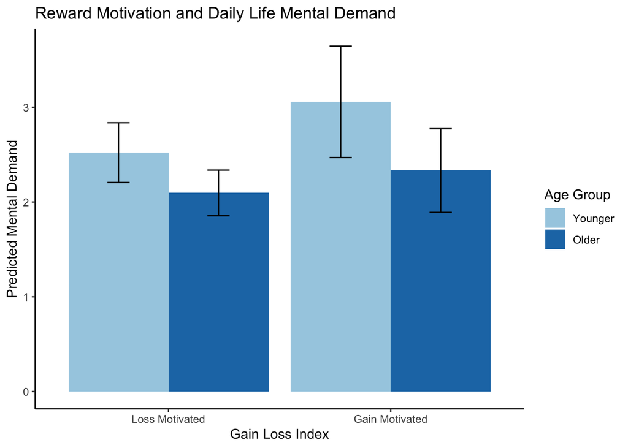

```r
CogED.reward.EMA <- ggpredict(m.mental.demand.age.timeDay.index.int, terms = c("GainLoss_index [≤0, >0]", "ageCode"))
CogED.reward.EMA$x <- factor(CogED.reward.EMA$x, levels = c(1,2), labels = c("Loss Motivated", "Gain Motivated"))

p.reward.EMA <- ggplot(CogED.reward.EMA, aes(x, predicted, fill=group)) +
  geom_bar(stat="identity", position=position_dodge()) +
  geom_errorbar(position=position_dodge(width=0.9), aes(ymin=conf.low, ymax=conf.high), width=.2) +
  theme_classic() + ggtitle("Reward Motivation and Daily Life Mental Demand") +
  scale_fill_brewer(palette = "Paired", "Age Group", labels = c("Younger","Older")) + labs(x="Gain Loss Index",y="Predicted Mental Demand")
p.reward.EMA
```

## Exploratory Analysis: Contribution of Subjective Value vs. Age Group on Daily Life Mental Demand

Exploratory analyses suggested that adding the subjective value estimates from the Cog-ED helped to explain additional variance in mental demand. Furthermore, the interaction between subjective value and age group helped to explain additional variance in daily life mental demand.

```r
# age + day of the week + time of the day + average Gain SV + average Loss SV (with age interactions) predicting mental demand
m.mental.demand.age.timeDay<- lmer(data = m.demand.time.day, mean.demand ~ ageCode + dayCode + timeCode + (1 | subjectid))

# age + day of the week + time of the day + average Gain SV + average Loss SV (with age interactions) predicting mental demand
m.mental.demand.age.timeDay.Gainloss<- lmer(data = m.demand.time.day, mean.demand ~ ageCode + dayCode + timeCode + meanSV_gain_c + meanSV_loss_c + (1 | subjectid))

table.age.SV <- tab_model(m.mental.demand.age.timeDay, m.mental.demand.age.timeDay.Gainloss, m.mental.demand.age.timeDay.Gainloss.int, pred.labels = c("Intercept", "Age Group", "Day of Week", "Time of Day", "SV (Gain)", "SV (Loss)", "Age Group * SV (Gain)", "Age Group * SV (Loss)"), dv.labels = c("Mental Demand Rating", "Mental Demand Rating", "Mental Demand Rating"), show.stat = T, show.icc = F, show.re.var = F, show.obs = F, show.r2 = F)
table.age.SV
```

|  | Mental Demand Rating |  |  |  | Mental Demand Rating |  |  |  | Mental Demand Rating |  |  |  |
| --- | --- | --- | --- | --- | --- | --- | --- | --- | --- | --- | --- | --- |
| Predictors | Estimates | CI | Statistic | p | Estimates | CI | Statistic | p | Estimates | CI | Statistic | p |
| Intercept | 2.09 | 1.99 – 2.18 | 43.39 | **<0.001** | 2.11 | 2.02 – 2.20 | 45.46 | **<0.001** | 2.13 | 2.04 – 2.22 | 45.85 | **<0.001** |
| Age Group | -0.09 | -0.22 – 0.03 | -1.46 | 0.143 | -0.13 | -0.25 – -0.00 | -2.03 | **0.043** | -0.14 | -0.26 – -0.02 | -2.24 | **0.025** |
| Day of Week | -0.05 | -0.06 – -0.04 | -9.55 | **<0.001** | -0.05 | -0.06 – -0.04 | -9.57 | **<0.001** | -0.05 | -0.06 – -0.04 | -9.52 | **<0.001** |
| Time of Day | -0.03 | -0.06 – -0.00 | -2.21 | **0.027** | -0.03 | -0.06 – -0.00 | -2.27 | **0.023** | -0.03 | -0.06 – -0.00 | -2.19 | **0.029** |
| SV (Gain) |  |  |  |  | 0.46 | 0.24 – 0.68 | 4.06 | **<0.001** | 0.75 | 0.42 – 1.09 | 4.38 | **<0.001** |
| SV (Loss) |  |  |  |  | -0.58 | -0.82 – -0.34 | -4.75 | **<0.001** | -1.01 | -1.39 – -0.63 | -5.19 | **<0.001** |
| Age Group * SV (Gain) |  |  |  |  |  |  |  |  | -0.49 | -0.93 – -0.05 | -2.18 | **0.030** |
| Age Group * SV (Loss) |  |  |  |  |  |  |  |  | 0.70 | 0.21 – 1.18 | 2.82 | **0.005** |
| N | 230 <sub>subjectid</sub> |  |  |  | 230 <sub>subjectid</sub> |  |  |  | 230 <sub>subjectid</sub> |  |  |  |